# Predicting Housing Prices

Shujing Yi, Yuehui Gong

2022-10-10

# Introduction

As Zillow has realized that its housing market predictions are not as accurate as they could be because they do not factor in enough local intelligence in Mecklenburg, this project is to improve Zillow’s housing market predictions for Mecklenburg.

To build a better housing price prediction regression model, our model includes three types of variables: external amenities, internal characteristics of houses from the given housing price dataset, and services from open data source, and spatial factors.

# Data Wrangling

The given housing price dataset includes the housing price and internal characteristics information for each housing point. It is input as the base dataset for further feather engineering.

```r
sale <-
  st_read("data/studentData.geojson") %>%
  st_transform('ESRI:102286')
glimpse(sale)
```

```
## Rows: 46,183
## Columns: 72
## $ lot_num    <chr> "05", "08", "21", "23", "27", "32", "33", "34", "37", "41",…
## $ nc_pin     <chr> "4621278868", "4621373722", "4621386474", "4621387621", "46…
## $ condo_town <dbl> 0, 0, 0, 0, 0, 0, 0, 0, 0, 0, 0, 0, 0, 0, 0, 0, 0, 0, 0, 0,…
## $ parcel_typ <dbl> 0, 0, 0, 0, 0, 0, 0, 0, 0, 0, 0, 0, 0, 0, 0, 0, 0, 0, 0, 0,…
## $ pid        <chr> "00101305", "00101308", "00101321", "00101323", "00101327",…
## $ legal_from <date> 2021-07-08, 2016-10-22, 2016-10-22, 2016-10-22, 2020-02-21…
## $ commonpid  <chr> "00101305", "00101308", "00101321", "00101323", "00101327",…
## $ taxpid     <chr> "00101305", "00101308", "00101321", "00101323", "00101327",…
## $ totalac    <dbl> 0.7700, 0.0000, 0.8500, 0.0000, 1.3400, 0.6000, 0.5000, 0.5…
## $ ownerlastn <chr> "FERGUSON", "EVANS", "THE BRENDA J DELUCA", "SELLERS", "SIG…
## $ ownerfirst <chr> "CODY WILLIAM", "ROBERT EMMETT III", "TRUST", "STEPHEN E", …
## $ cownerfirs <chr> "ALLISON ELISABETGH", "MARY-ELLEN KUUIPO", NA, "CRYSTAL L",…
## $ cownerlast <chr> "FERGUSON", "EVANS", NA, "SELLERS", "SIGLER", "GREINER", NA…
```

[output cut: 59 more lines]

```r
Mecklenberg <-
  st_read("data/zipcode/zipcode.shp") %>%
  st_transform('ESRI:102286')
```

The following map visualize the distribution of housing points and their prices, which is represented in color.

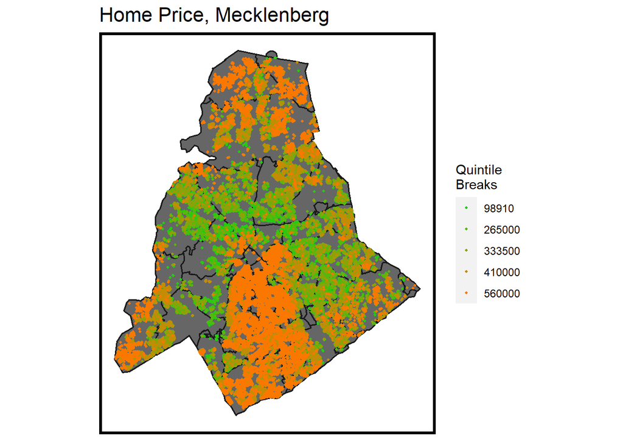

```r
ggplot() +
  geom_sf(data=Mecklenberg,fill = "grey40", color = "grey10",size= 0.7)+
  geom_sf(data = sale, aes(colour = q5(as.numeric(price))),
          show.legend = "point", size = .75) +
  scale_colour_manual(values = palette5,
                   labels=qBr(sale,"price"),
                   name="Quintile\nBreaks") +
  labs(title="Home Price, Mecklenberg") +
  mapTheme()
```

## External Amenities

The first part of variables our model is using is the external amenities, the proximity to which could add value to houses. To get the data, we are using the open data portal for Mecklenburg. (http://maps.co.mecklenburg.nc.us/openmapping/data.html)

Our model is considering the following amenities and services: -Public Transportation: bus stop, station -Public Amenities: park, school -Potential negative factors: homeless shelter, flood, Landfill

### Bus Stop

```r
busstop <- st_read("data/cats_busstops/CATS_BusStops.shp") #%>%
```

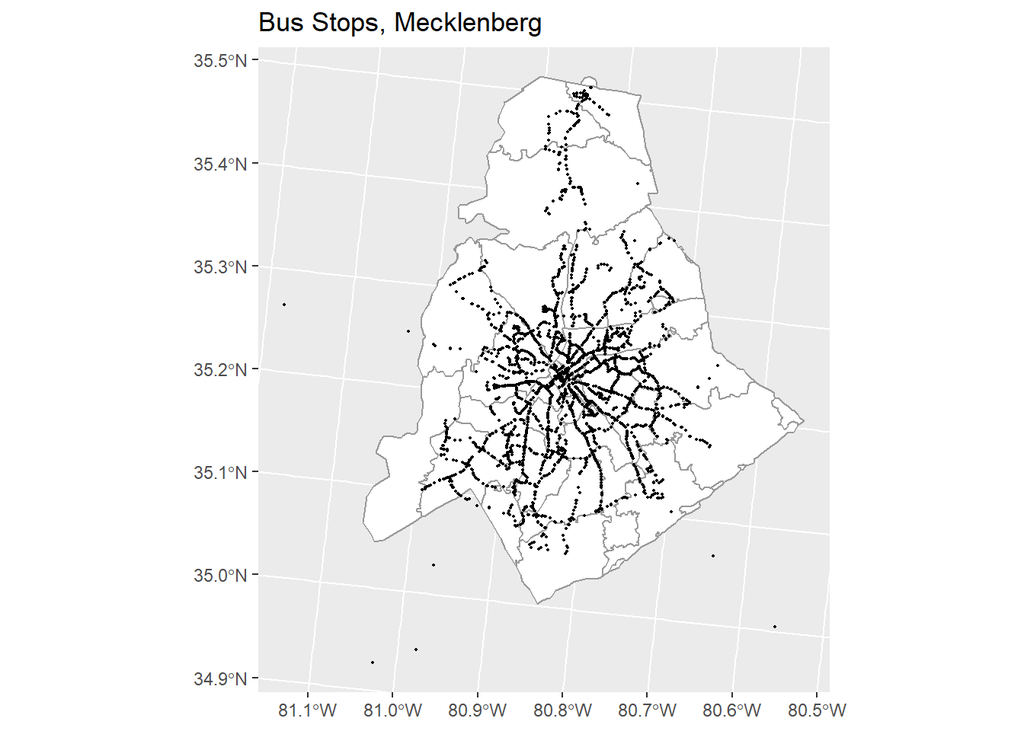

```r
#st_transform(st_crs(tracts20))
ggplot() +
 geom_sf(data=Mecklenberg,fill = "white", color = "grey60",size= 0.5)+
  geom_sf(data = busstop,size= 0.3)+
    labs(title = "Bus Stops, Mecklenberg")
```

```r
sale <-
  sale %>%
    mutate(bus_nn1 = nn_function(st_coordinates(sale), st_coordinates(busstop), 1))
```

### Station

```r
station<- st_read("data/station_merge/station_merge.shp")
```

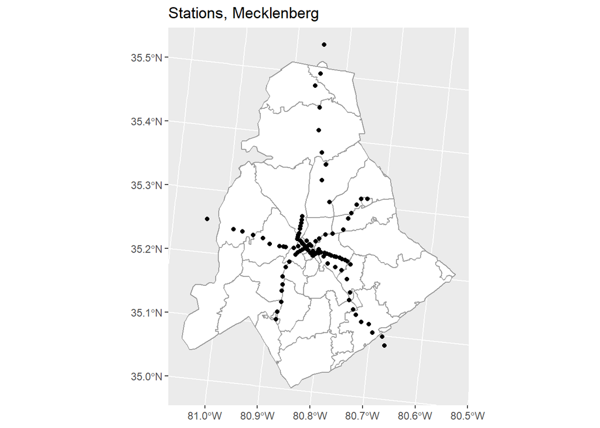

```r
ggplot() +
 geom_sf(data=Mecklenberg,fill = "white", color = "grey60",size= 0.5)+
    geom_sf(data = station) +
    labs(title = "Stations, Mecklenberg")
```

```r
sale <-
  sale %>%
    mutate(station_nn1 = nn_function(st_coordinates(sale), st_coordinates(station), 1))
```

### Park

```r
park <- st_read("data/park_locations/Park_Locations.shp") %>%
              st_transform(st_crs(Mecklenberg))
```

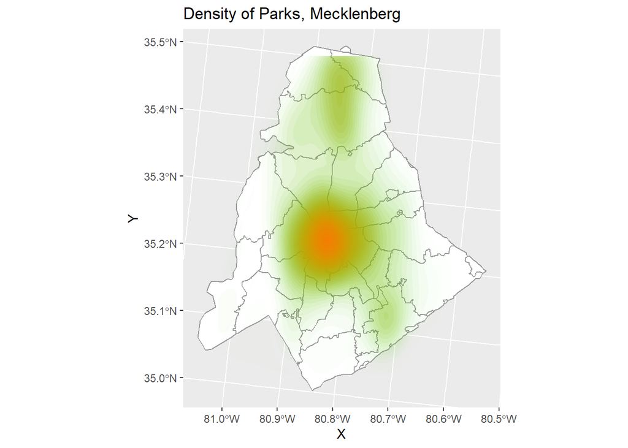

```r
ggplot() + geom_sf(data=Mecklenberg,fill = "white", color = "grey60",size= 0.5)+
  stat_density2d(data = data.frame(st_coordinates(park)),
                 aes(X, Y, fill = ..level.., alpha = ..level..),
                 size = 0.01, bins = 40, geom = 'polygon') +
  scale_fill_gradient(low = "#25CB10", high = "#FA7800",
                      breaks=c(0.000000003,0.00000003),
                      labels=c("Minimum","Maximum"), name = "Density") +
  scale_alpha(range = c(0.00, 0.35), guide = FALSE) +
  labs(title = "Density of Parks, Mecklenberg")
```

Calculate distance to the nearest park as park_nn1:

```r
sale <-
  sale %>%
    mutate(park_nn1 = nn_function(st_coordinates(sale), st_coordinates(park), 1),
           park_nn3 = nn_function(st_coordinates(sale), st_coordinates(park), 3))
```

### School

```r
school_public <- st_read("data/cms_schools/CMS_Schools.shp") %>%
              st_transform(st_crs(Mecklenberg)) %>%
  dplyr::select(city, address)
```

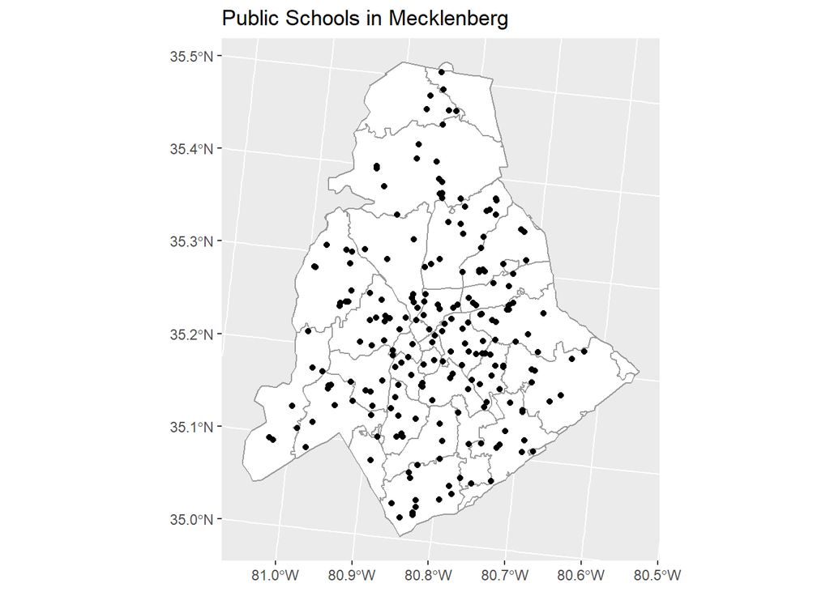

```r
school_charter <- st_read("data/schools_charter/Schools_Charter.shp") %>%
              st_transform(st_crs(Mecklenberg)) %>%
    dplyr::select(city, address)
school<-rbind(school_public,school_charter)

ggplot()+
    geom_sf(data=Mecklenberg,fill = "white", color = "grey60",size= 0.5)+
  geom_sf(data=school)+
    labs(title = "Public Schools in Mecklenberg")
```

```r
sale <-
  sale %>%
    mutate(school_nn1 = nn_function(st_coordinates(sale), st_coordinates(school), 1),
   school_nn2 = nn_function(st_coordinates(sale), st_coordinates(school), 2),
   school_nn3 = nn_function(st_coordinates(sale), st_coordinates(school), 3))
```

### Homeless Shelter

```r
homelessshelter <- st_read("data/homeless_shelters/Homeless_Shelters.shp") %>%
              st_transform(st_crs(Mecklenberg))
```

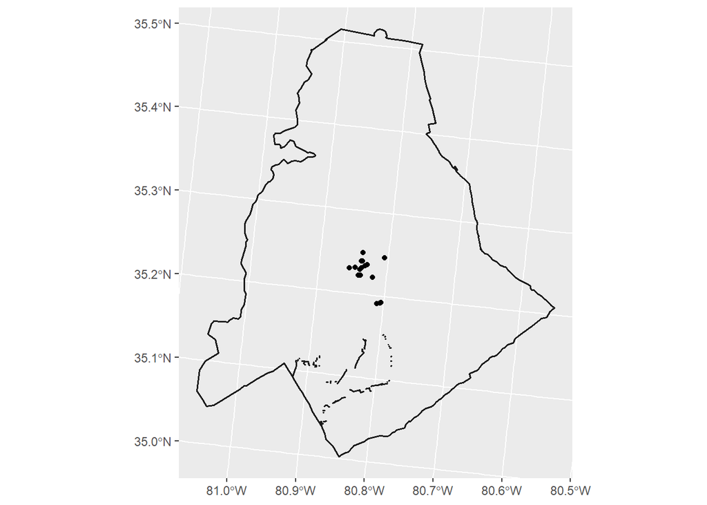

```r
ggplot() +
  geom_sf(data = homelessshelter, fill = "red") +
  geom_sf(data=st_union(Mecklenberg),fill = "transparent", color = "grey10",size= 0.7)
```

[figure not shown]

```r
ggplot() + geom_sf(data=st_union(Mecklenberg), color = "grey10",size= 0.7) +
  stat_density2d(data = data.frame(st_coordinates(homelessshelter)),
                 aes(X, Y, fill = ..level.., alpha = ..level..),
                 size = 0.01, bins = 40, geom = 'polygon') +
  scale_fill_gradient(low = "#25CB10", high = "#FA7800",
                      breaks=c(0.000000003,0.00000003),
                      labels=c("Minimum","Maximum"), name = "Density") +
  scale_alpha(range = c(0.00, 0.35), guide = FALSE) +
  labs(title = "Density of Aggravated Assaults, Boston") +
  mapTheme()
```

```r
sale <-
  sale %>%
    mutate(homelessshelter_nn1 = nn_function(st_coordinates(sale), st_coordinates(homelessshelter), 1))
```

### Landfill

```r
landfill <- st_read("data/landfills/Landfills.shp") %>%
              st_transform(st_crs(Mecklenberg))
```

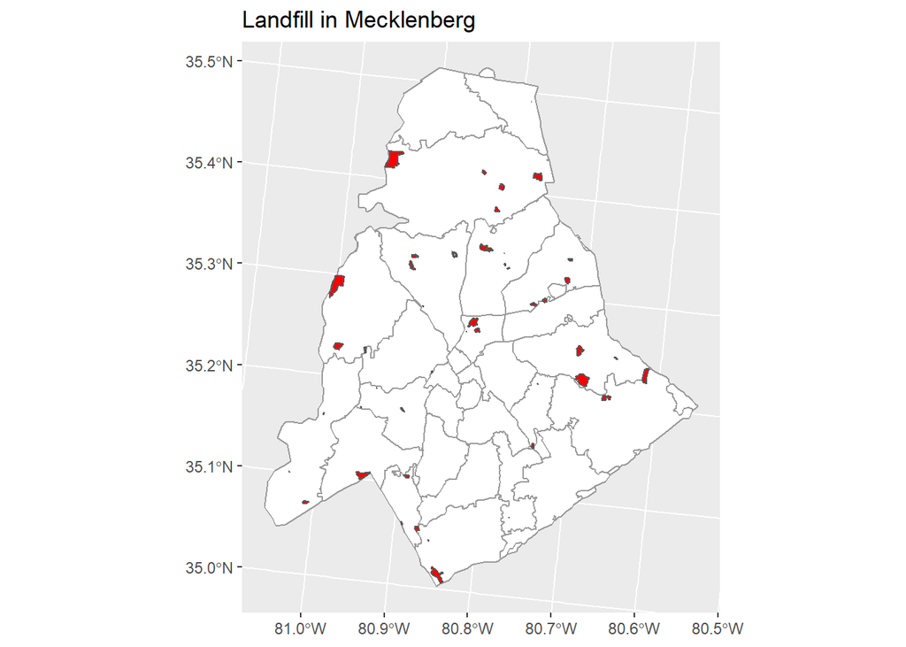

```r
ggplot() +
  geom_sf(data=Mecklenberg,fill = "white", color = "grey60",size= 0.5)+
  geom_sf(data = landfill, fill = "red") +
   labs(title = "Landfill in Mecklenberg")
```

```r
sale <-
  sale %>%
    mutate(landfill = nn_function(st_coordinates(sale), st_coordinates(st_centroid(landfill)), 1))
```

### Floodplain

```r
flood100y <- st_read("data/femaexisting_100yr_floodplain/FEMAExisting_100yr_Floodplain.shp") %>%
              st_transform(st_crs(Mecklenberg))
```

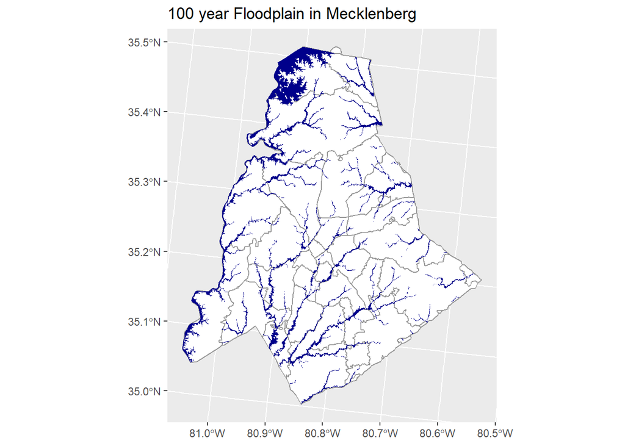

```r
ggplot() +
  geom_sf(data=Mecklenberg,fill = "white", color = "grey60",size= 0.5)+
  geom_sf(data = flood100y, fill = "dark blue",color="transparent") +
  labs(title = "100 year Floodplain in Mecklenberg")
```

```r
salegroup <-
  rbind(
    sale[flood100y,] %>%
      st_drop_geometry() %>%
      left_join(sale) %>%
      st_sf() %>%
      mutate(flood100y = 1),
   sale[flood100y, op = st_disjoint] %>%
      st_drop_geometry() %>%
      left_join(sale) %>%
      st_sf() %>%
      mutate(flood100y = 0))

salegroup <- salegroup[!duplicated(salegroup$musaID), ]
```

Map the houses within floodplain (flood100y == 1)

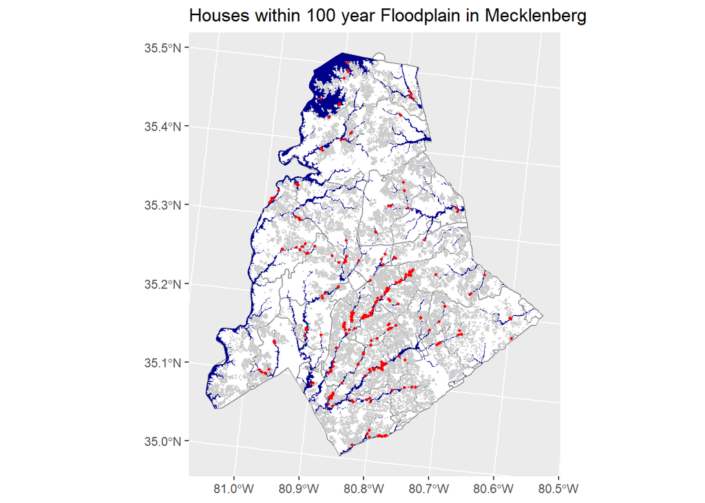

```r
floodpt<-
  salegroup %>%
  filter(flood100y == 1)

ggplot() +
  geom_sf(data=Mecklenberg,fill = "white", color = "grey60",size= 0.5)+
  geom_sf(data = flood100y, fill = "dark blue",color="transparent") +
     geom_sf(data = salegroup,  col = "grey80",
          show.legend = "point", size = .2) +
  geom_sf(data = floodpt, col = "red",
          show.legend = "point", size = .7) +
  labs(title = "Houses within 100 year Floodplain in Mecklenberg")
```

## Internal Characteristics

### Age

Age calculation

```r
salegroup <-
  salegroup %>%
  mutate(age = 2022 - yearbuilt)
```

##Test

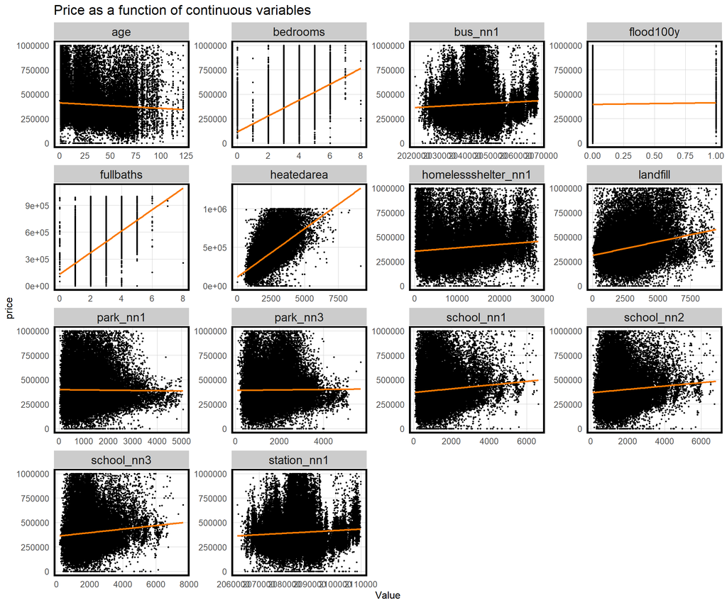

```r
st_drop_geometry(salegroup) %>%
  dplyr::select(price, age, heatedarea, fullbaths, bedrooms,homelessshelter_nn1,park_nn1,park_nn3,landfill,flood100y,school_nn1,school_nn2,school_nn3,bus_nn1,station_nn1) %>%
  filter(price <= 1000000, age<500, bedrooms<20) %>%
  gather(Variable, Value, -price) %>%

   ggplot(aes(Value, price)) +
     geom_point(size = .5) + geom_smooth(method = "lm", se=F, colour = "#FA7800") +
     facet_wrap(~Variable, ncol = 4, scales = "free") +
     labs(title = "Price as a function of continuous variables") +
     plotTheme()
```

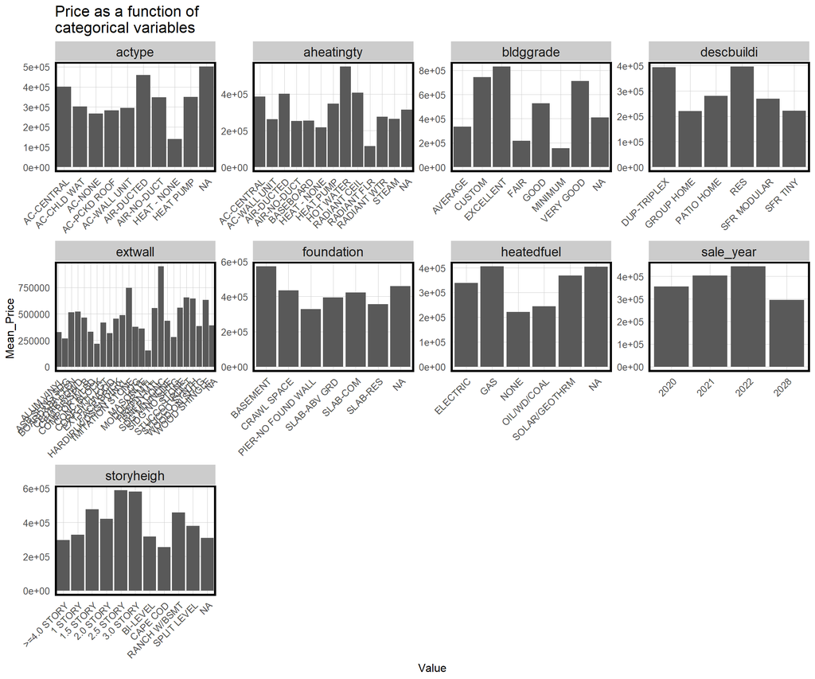

```r
st_drop_geometry(salegroup) %>%
  dplyr::select(price, descbuildi, storyheigh, aheatingty, heatedfuel,actype,extwall,foundation, bldggrade,
                sale_year) %>%
  filter(price <= 1000000) %>%
  gather(Variable, Value, -price) %>%
   ggplot(aes(Value, price)) +
     geom_bar(position = "dodge", stat = "summary", fun.y = "mean") +
     facet_wrap(~Variable, ncol = 4, scales = "free") +
     labs(title = "Price as a function of\ncategorical variables", y = "Mean_Price") +
     plotTheme() + theme(axis.text.x = element_text(angle = 45, hjust = 1))
```

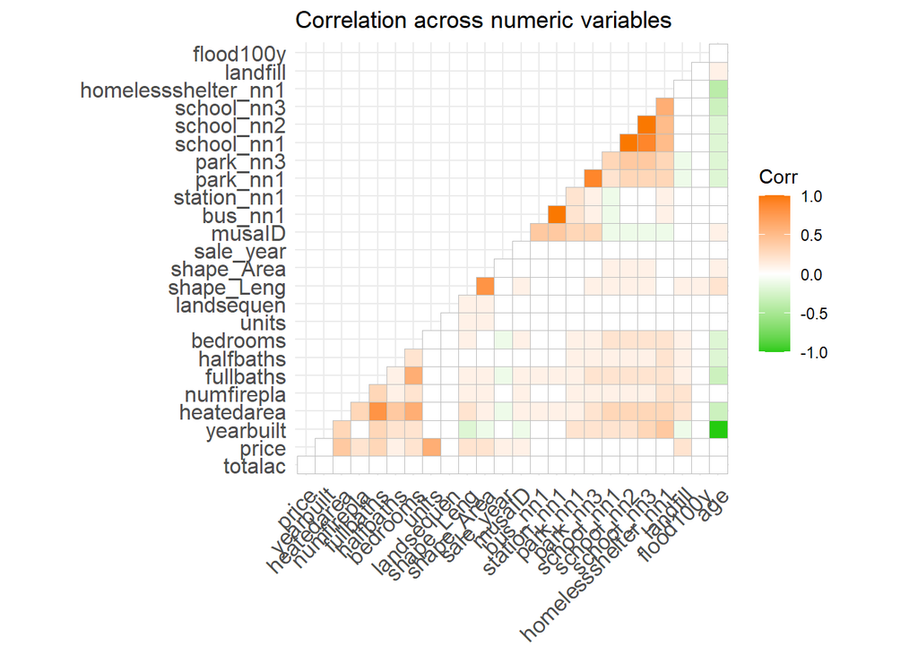

```r
numericVars <-
  select_if(st_drop_geometry(salegroup), is.numeric) %>% na.omit()

ggcorrplot(
  round(cor(numericVars), 1),
  p.mat = cor_pmat(numericVars),
  colors = c("#25CB10", "white", "#FA7800"),
  type="lower",
  insig = "blank") +
    labs(title = "Correlation across numeric variables")
```

##categorical change

### Age

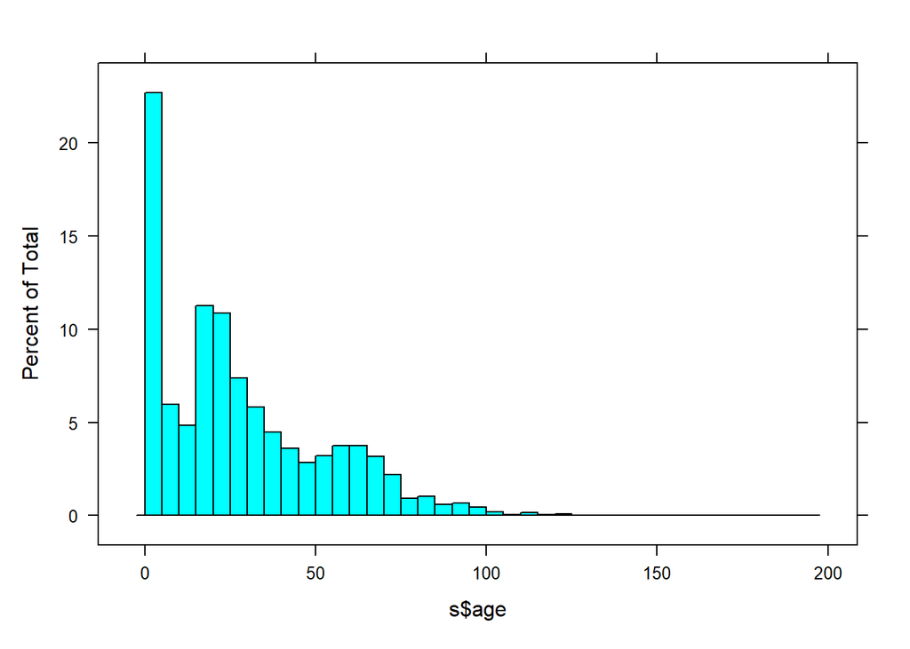

```r
s <-salegroup %>%
  filter(age <= 200)
histogram(s$age,breaks=40)
```

```r
salegroup <-
  salegroup %>%
  mutate(age.cat = case_when(
                  age >= 0 & age <15  ~ "Up to 15yrs",
                  age >= 15 & age < 50  ~ "15-50yrs",
                  age >= 50 & age < 75  ~ "50-75yrs",
                  age >= 75  ~ "75+yrs"),)
```

### Story height

```r
glimpse(s$storyheigh)
```

```
##  chr [1:46178] "2.0 STORY" "2.0 STORY" "2.5 STORY" "2.0 STORY" "2.0 STORY" ...
```

```r
salegroup$story.cat <- recode(salegroup$storyheigh,"1.0 STORY"= "1story","1 STORY"= "1story", "1.5 STORY" = "2story", "2.0 STORY" = "2story","BI-LEVEL"="2story","SPLIT LEVEL"="2story","2.5 STORY"="3story","3.0 STORY"="3story","CAPE COD"="other","RANCH W/BSMT"="other")
```

## Spatial Factors

### Census Tract

```r
census_api_key("a78f5d0c0fd577cd3f16136b5a87d6ecdb62ffba", overwrite = TRUE)

tracts <-
  get_acs(geography = "tract",
          variables = c("B25026_001E","B02001_002E",
                        "B15001_050E","B15001_009E",
                        "B19013_001E", "B25058_001E",
                        "B06012_002E"),
          year=2020, state="NC",
          county="Mecklenburg County", geometry=TRUE) %>%
  st_transform('ESRI:102286')
tracts <-
  tracts %>%
  dplyr::select( -NAME, -moe) %>%
  spread(variable, estimate) %>%
  rename(TotalPop = B25026_001,
         Whites = B02001_002,
         FemaleBachelors = B15001_050,
         MaleBachelors = B15001_009,
         MedHHInc = B19013_001,
         MedRent = B25058_001,
         TotalPoverty = B06012_002)

tracts <-
  tracts %>%
  mutate(pctWhite = ifelse(TotalPop > 0, Whites / TotalPop, 0),
         pctBachelors = ifelse(TotalPop > 0, ((FemaleBachelors + MaleBachelors) / TotalPop), 0),
         pctPoverty = ifelse(TotalPop > 0, TotalPoverty / TotalPop, 0)) %>%
  dplyr::select(-Whites,-FemaleBachelors,-MaleBachelors,-TotalPoverty)
```

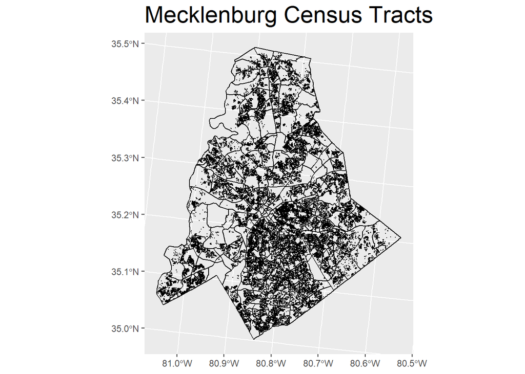

```r
ggplot()+
  geom_sf(data = tracts, fill = "transparent", color = "black")+
  geom_sf(data=salegroup,
          show.legend = "point", size= 0.1) +
  labs(title = "Mecklenburg Census Tracts") +
  theme(plot.title = element_text(size=22))
```

###Intersection

```r
salegroup<-st_intersection(salegroup,tracts)
```

```r
salegroup<-st_intersection(salegroup,Mecklenberg)
```

# Regression Model

```r
reg1 <- lm(price ~ ., data = st_drop_geometry(salegroup) %>%
                                 dplyr::select(price, zip,heatedarea, bedrooms,
                                               age.cat,storyheigh,fullbaths, halfbaths,
                                               numfirepla,foundation,heatedfuel,actype,units,accounttyp, park_nn1,homelessshelter_nn1,landfill,flood100y,school_nn1,bus_nn1,station_nn1,bldggrade,
                                               TotalPop,pctWhite,pctBachelors,pctPoverty,MedHHInc))
summary(reg1)
```

```
##
## Call:
## lm(formula = price ~ ., data = st_drop_geometry(salegroup) %>%
##     dplyr::select(price, zip, heatedarea, bedrooms, age.cat,
##         storyheigh, fullbaths, halfbaths, numfirepla, foundation,
##         heatedfuel, actype, units, accounttyp, park_nn1, homelessshelter_nn1,
##         landfill, flood100y, school_nn1, bus_nn1, station_nn1,
##         bldggrade, TotalPop, pctWhite, pctBachelors, pctPoverty,
##         MedHHInc))
##
## Residuals:
##      Min       1Q   Median       3Q      Max
## -1958925   -84381   -17450    53412 43721516
##
## Coefficients:
##                                Estimate Std. Error t value Pr(>|t|)
## (Intercept)                  -4.022e+07  5.380e+06  -7.476 7.79e-14 ***
## zip28031                      3.116e+05  1.475e+05   2.112 0.034668 *
## zip28036                      1.351e+05  1.474e+05   0.917 0.359351
## zip28078                      1.053e+05  1.469e+05   0.717 0.473451
## zip28104                      2.473e+05  1.637e+05   1.511 0.130772
## zip28105                      2.630e+05  1.500e+05   1.754 0.079507 .
## zip28107                      1.640e+05  1.891e+05   0.867 0.385999
## zip28134                      2.698e+05  1.504e+05   1.794 0.072851 .
## zip28202                      2.165e+05  1.791e+05   1.209 0.226688
## zip28203                      3.546e+05  1.498e+05   2.368 0.017894 *
## zip28204                      3.155e+05  1.521e+05   2.074 0.038102 *
## zip28205                      2.663e+05  1.486e+05   1.792 0.073179 .
## zip28206                      1.941e+05  1.498e+05   1.296 0.195004
## zip28207                      5.873e+05  1.510e+05   3.890 0.000100 ***
## zip28208                      1.621e+05  1.484e+05   1.092 0.274872
## zip28209                      3.711e+05  1.493e+05   2.485 0.012954 *
## zip28210                      2.508e+05  1.495e+05   1.678 0.093445 .
## zip28211                      3.481e+05  1.495e+05   2.328 0.019927 *
## zip28212                      2.309e+05  1.493e+05   1.546 0.122118
## zip28213                      1.478e+05  1.481e+05   0.998 0.318325
## zip28214                      8.750e+04  1.478e+05   0.592 0.553893
## zip28215                      2.473e+05  1.482e+05   1.668 0.095275 .
## zip28216                      1.265e+05  1.476e+05   0.857 0.391517
## zip28217                      1.989e+05  1.496e+05   1.330 0.183683
```

[output cut: 59 more lines]

```
## bldggradeGOOD                 6.033e+04  5.559e+03  10.853  < 2e-16 ***
## bldggradeMINIMUM             -8.073e+04  8.312e+04  -0.971 0.331410
## bldggradeVERY GOOD            2.221e+05  9.040e+03  24.565  < 2e-16 ***
## TotalPop                     -2.389e+00  1.614e+00  -1.480 0.138756
## pctWhite                      8.477e+04  1.443e+04   5.874 4.29e-09 ***
## pctBachelors                  2.031e+05  1.541e+05   1.318 0.187509
## pctPoverty                    1.419e+05  3.465e+04   4.096 4.21e-05 ***
## MedHHInc                      7.875e-01  9.253e-02   8.511  < 2e-16 ***
## ---
## Signif. codes:  0 '***' 0.001 '**' 0.01 '*' 0.05 '.' 0.1 ' ' 1
##
## Residual standard error: 386900 on 45997 degrees of freedom
##   (90 observations deleted due to missingness)
## Multiple R-squared:  0.5884, Adjusted R-squared:  0.5875
## F-statistic: 730.5 on 90 and 45997 DF,  p-value: < 2.2e-16
```

# Cross validation

```r
inTrain <- createDataPartition(
              y = paste(salegroup$storyheigh.cat, salegroup$heatedfuel, salegroup$actype),
              p = .60, list = FALSE)
Mecklenberg.training <- salegroup[inTrain,]
Mecklenberg.test <- salegroup[-inTrain,]
```

```r
reg.training <- lm(price ~ ., data = st_drop_geometry(Mecklenberg.training) %>%
                                 dplyr::select(price, heatedarea, bedrooms,
                                               age.cat,story.cat,fullbaths, halfbaths,
                                               numfirepla,foundation,heatedfuel,actype,units,accounttyp, park_nn1,homelessshelter_nn1,landfill,flood100y,school_nn1,bus_nn1,station_nn1,bldggrade,
                                               TotalPop,pctWhite,pctBachelors,pctPoverty,MedHHInc))
summary(reg.training)
```

```
##
## Call:
## lm(formula = price ~ ., data = st_drop_geometry(Mecklenberg.training) %>%
##     dplyr::select(price, heatedarea, bedrooms, age.cat, story.cat,
##         fullbaths, halfbaths, numfirepla, foundation, heatedfuel,
##         actype, units, accounttyp, park_nn1, homelessshelter_nn1,
##         landfill, flood100y, school_nn1, bus_nn1, station_nn1,
##         bldggrade, TotalPop, pctWhite, pctBachelors, pctPoverty,
##         MedHHInc))
##
## Residuals:
##      Min       1Q   Median       3Q      Max
## -1961316   -90190   -20472    54426 43748037
##
## Coefficients:
##                                Estimate Std. Error t value Pr(>|t|)
## (Intercept)                  -9.678e+06  1.679e+06  -5.763 8.33e-09 ***
## heatedarea                    1.274e+02  4.888e+00  26.071  < 2e-16 ***
## bedrooms                     -6.472e+03  2.970e+03  -2.179 0.029341 *
## age.cat50-75yrs               3.672e+04  9.064e+03   4.051 5.11e-05 ***
## age.cat75+yrs                 1.227e+05  1.363e+04   9.002  < 2e-16 ***
## age.catUp to 15yrs            3.460e+04  6.445e+03   5.369 8.00e-08 ***
## story.cat1story               7.819e+04  2.241e+05   0.349 0.727117
## story.cat2story               3.594e+04  2.240e+05   0.160 0.872542
## story.cat3story              -8.800e+03  2.244e+05  -0.039 0.968717
## story.catother                4.671e+04  2.252e+05   0.207 0.835701
## fullbaths                     2.527e+04  5.291e+03   4.777 1.79e-06 ***
## halfbaths                     1.542e+04  5.907e+03   2.611 0.009024 **
## numfirepla                    4.327e+03  5.936e+03   0.729 0.466056
## foundationCRAWL SPACE         5.607e+04  1.838e+04   3.051 0.002284 **
## foundationPIER-NO FOUND WALL  6.460e+05  2.748e+05   2.351 0.018726 *
## foundationSLAB-ABV GRD        9.836e+04  7.701e+04   1.277 0.201531
## foundationSLAB-COM            1.634e+05  1.945e+05   0.840 0.400865
## foundationSLAB-RES            5.542e+04  1.892e+04   2.929 0.003407 **
## heatedfuelGAS                 2.100e+03  7.213e+03   0.291 0.770909
## heatedfuelNONE                1.074e+05  6.168e+04   1.741 0.081624 .
## heatedfuelOIL/WD/COAL         8.879e+04  3.365e+04   2.639 0.008323 **
## heatedfuelSOLAR/GEOTHRM       4.059e+04  1.588e+05   0.256 0.798228
## actypeAC-CHLD WAT            -1.486e+04  2.238e+05  -0.066 0.947038
## actypeAC-NONE                -4.997e+04  1.468e+04  -3.405 0.000663 ***
```

[output cut: 23 more lines]

```
## bldggradeGOOD                 7.398e+04  6.927e+03  10.680  < 2e-16 ***
## bldggradeMINIMUM             -1.047e+05  9.729e+04  -1.076 0.281748
## bldggradeVERY GOOD            2.602e+05  1.126e+04  23.105  < 2e-16 ***
## TotalPop                     -5.449e+00  1.948e+00  -2.797 0.005160 **
## pctWhite                      1.327e+05  1.400e+04   9.482  < 2e-16 ***
## pctBachelors                  3.936e+05  1.851e+05   2.127 0.033425 *
## pctPoverty                    2.416e+05  4.023e+04   6.004 1.95e-09 ***
## MedHHInc                      1.097e+00  1.053e-01  10.419  < 2e-16 ***
## ---
## Signif. codes:  0 '***' 0.001 '**' 0.01 '*' 0.05 '.' 0.1 ' ' 1
##
## Residual standard error: 387200 on 27607 degrees of freedom
##   (55 observations deleted due to missingness)
## Multiple R-squared:  0.6581, Adjusted R-squared:  0.6574
## F-statistic:   984 on 54 and 27607 DF,  p-value: < 2.2e-16
```

##Test Set

```r
Mecklenberg.test <-
  Mecklenberg.test %>%
  mutate(Regression = "Baseline Regression",
         SalePrice.Predict = predict(reg.training, Mecklenberg.test),
         SalePrice.Error = SalePrice.Predict - price,
         SalePrice.AbsError = abs(SalePrice.Predict - price),
         SalePrice.APE = (abs(SalePrice.Predict - price)) / SalePrice.Predict)%>%
  filter(price < 5000000)
```

[figure not shown]

```r
ggplot() +
  geom_sf(data=Mecklenberg,fill = "grey40", color = "grey10",size= 0.7)+
  geom_sf(data = Mecklenberg.test, aes(colour = q5(as.numeric(SalePrice.AbsError))),
          show.legend = "point", size = .75) +
  scale_colour_manual(values = palette5,
                   labels=qBr(sale,"price"),
                   name="Quintile\nBreaks") +
  labs(title="Home Price Absolute Error, Mecklenberg") +
  mapTheme()
```

```r
fitControl <- trainControl(method = "cv", number = 100)
set.seed(825)

reg.cv <-
  train(price ~ ., data = st_drop_geometry(salegroup) %>%
                                dplyr::select(price, heatedarea, bedrooms,
                                               age.cat,story.cat,fullbaths, halfbaths,
                                               numfirepla,foundation,heatedfuel,actype,units,accounttyp, park_nn1,homelessshelter_nn1,landfill,flood100y,school_nn1,bus_nn1,station_nn1,bldggrade,
                                               TotalPop,pctWhite,pctBachelors,pctPoverty,MedHHInc),
     method = "lm", trControl = fitControl, na.action = na.pass)

reg.cv
```

```
## Linear Regression
##
## 46178 samples
##    25 predictor
##
## No pre-processing
## Resampling: Cross-Validated (100 fold)
## Summary of sample sizes: 45716, 45716, 45715, 45717, 45717, 45716, ...
## Resampling results:
##
##   RMSE      Rsquared   MAE
##   310519.3  0.6287609  123475
##
## Tuning parameter 'intercept' was held constant at a value of TRUE
```

```r
reg.cv$resample[1:5,]
```

```
##       RMSE  Rsquared      MAE Resample
## 1 166000.1 0.7703449 108719.1  Fold001
## 2 316017.7 0.4499814 119642.1  Fold002
## 3 217648.0 0.5656577 120717.1  Fold003
## 4 156343.3 0.6954529 101596.3  Fold004
## 5 229284.6 0.6377856 117982.7  Fold005
```

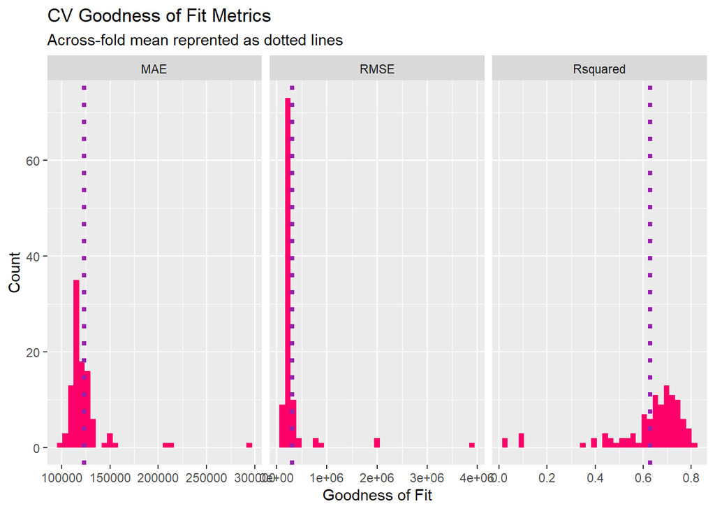

```r
dplyr::select(reg.cv$resample, -Resample) %>%
  gather(metric, value) %>%
  left_join(gather(reg.cv$results[2:4], metric, mean)) %>%
  ggplot(aes(value)) +
    geom_histogram(bins=35, fill = "#FF006A") +
    facet_wrap(~metric,scales = "free_x") +
    geom_vline(aes(xintercept = mean), colour = "#981FAC", linetype = 3, size = 1.5) +

    labs(x="Goodness of Fit", y="Count", title="CV Goodness of Fit Metrics",
         subtitle = "Across-fold mean reprented as dotted lines")
```

#Spatial Correlation of error

```r
coords.test <- st_coordinates(Mecklenberg.test)

neighborList.test <- knn2nb(knearneigh(coords.test, 5))

spatialWeights.test <- nb2listw(neighborList.test, style="W")

Mecklenberg.test$lagPrice <- lag.listw(spatialWeights.test, Mecklenberg.test$price)
Mecklenberg.test$lagPriceError<-lag.listw(spatialWeights.test, Mecklenberg.test$SalePrice.Error, NAOK = TRUE)

#Mecklenberg.test %>%
  #mutate(lagPriceError = lag.listw(spatialWeights.test, SalePrice.Error, NAOK = TRUE)) %>%
  #ggplot(aes(lagPriceError, SalePrice.Error))
```

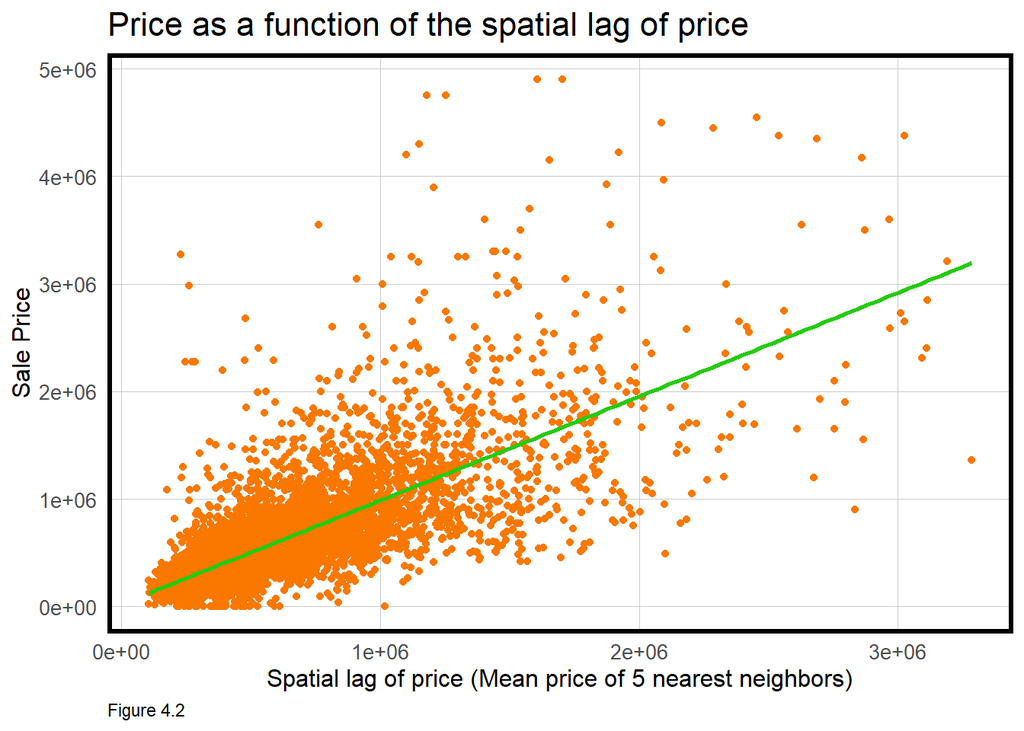

```r
ggplot(Mecklenberg.test, aes(x=lagPrice, y=price)) +
  geom_point(colour = "#FA7800") +
  geom_smooth(method = "lm", se = FALSE, colour = "#25CB10") +
  labs(title = "Price as a function of the spatial lag of price",
       caption = "Figure 4.2",
       x = "Spatial lag of price (Mean price of 5 nearest neighbors)",
       y = "Sale Price") +
  plotTheme()
```

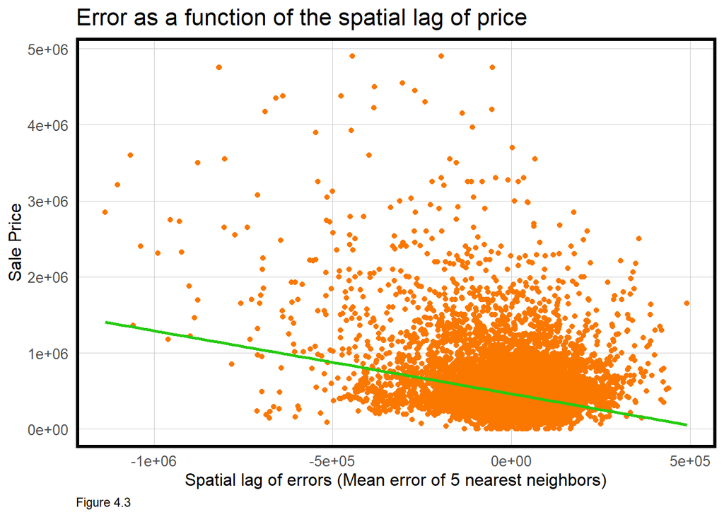

```r
ggplot(Mecklenberg.test, aes(x=lagPriceError, y=price)) +
  geom_point(colour = "#FA7800") +
  geom_smooth(method = "lm", se = FALSE, colour = "#25CB10") +
  labs(title = "Error as a function of the spatial lag of price",
       caption="Figure 4.3",
       x = "Spatial lag of errors (Mean error of 5 nearest neighbors)",
       y = "Sale Price") +
  plotTheme()
```

#Moran’s

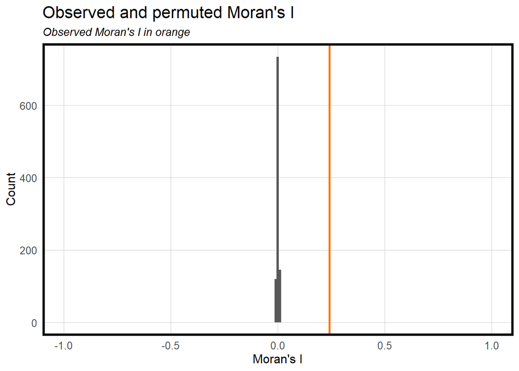

```r
moranTest <- moran.mc(Mecklenberg.test$SalePrice.Error,
                      spatialWeights.test, nsim = 999, na.action=na.omit)

ggplot(as.data.frame(moranTest$res[c(1:999)]), aes(moranTest$res[c(1:999)])) +
  geom_histogram(binwidth = 0.01) +
  geom_vline(aes(xintercept = moranTest$statistic), colour = "#FA7800",size=1) +
  scale_x_continuous(limits = c(-1, 1)) +
  labs(title="Observed and permuted Moran's I",
       subtitle= "Observed Moran's I in orange",
       x="Moran's I",
       y="Count") +
  plotTheme()
```

#Accounting for neighborhood

```r
# Errors by neighborhood
left_join(
  st_drop_geometry(Mecklenberg.test) %>%
    group_by(zip) %>%
    summarize(meanPrice = mean(price, na.rm = T)),
  mutate(Mecklenberg.test, predict.fe =
                        predict(lm(price ~ zip, data = Mecklenberg.test),
                        Mecklenberg.test)) %>%
    st_drop_geometry %>%
    group_by(zip) %>%
      summarize(meanPrediction = mean(predict.fe))) %>%
      kable() %>% kable_styling()
```

| zip | meanPrice | meanPrediction |
| --- | --- | --- |
| 28027 | 397375.0 | 397375.0 |
| 28031 | 720251.3 | 720251.3 |
| 28036 | 602794.0 | 602794.0 |
| 28078 | 454047.4 | 454047.4 |
| 28104 | 525725.0 | 525725.0 |
| 28105 | 414318.1 | 414318.1 |
| 28134 | 369500.0 | 369500.0 |
| 28202 | 715333.3 | 715333.3 |
| 28203 | 877150.0 | 877150.0 |
| 28204 | 827716.4 | 827716.4 |
| 28205 | 498419.4 | 498419.4 |
| 28206 | 310170.5 | 310170.5 |
| 28207 | 1739608.0 | 1739608.0 |
| 28208 | 281159.6 | 281159.6 |
| 28209 | 816997.9 | 816997.9 |
| 28210 | 558121.5 | 558121.5 |
| 28211 | 951015.4 | 951015.4 |
| 28212 | 276146.6 | 276146.6 |
| 28213 | 293139.6 | 293139.6 |
| 28214 | 303894.9 | 303894.9 |
| 28215 | 308532.6 | 308532.6 |
| 28216 | 306127.0 | 306127.0 |
| 28217 | 260483.2 | 260483.2 |
| 28226 | 669341.1 | 669341.1 |
| 28227 | 350417.7 | 350417.7 |
| 28262 | 339856.0 | 339856.0 |
| 28269 | 320502.9 | 320502.9 |
| 28270 | 576002.6 | 576002.6 |
| 28273 | 334026.4 | 334026.4 |
| 28277 | 586787.6 | 586787.6 |
| 28278 | 467873.1 | 467873.1 |

```r
reg.nhood <- lm(price ~ ., data = as.data.frame(Mecklenberg.training) %>%
                                 dplyr::select(zip, price, heatedarea, bedrooms,
                                               age.cat,story.cat,fullbaths, halfbaths,
                                               numfirepla,foundation,heatedfuel,actype,units,accounttyp, park_nn1,homelessshelter_nn1,landfill,flood100y,school_nn1,bus_nn1,station_nn1,bldggrade,
                                               TotalPop,pctWhite,pctBachelors,pctPoverty,MedHHInc))

Mecklenberg.test.nhood <-
  Mecklenberg.test %>%
  mutate(Regression = "Neighborhood Effects",
         SalePrice.Predict = predict(reg.nhood, Mecklenberg.test),
         SalePrice.Error = SalePrice.Predict- price,
         SalePrice.AbsError = abs(SalePrice.Predict- price),
         SalePrice.APE = (abs(SalePrice.Predict- price)) / price)%>%
  filter(price < 5000000)
```

```r
summary(reg.nhood)
```

```
##
## Call:
## lm(formula = price ~ ., data = as.data.frame(Mecklenberg.training) %>%
##     dplyr::select(zip, price, heatedarea, bedrooms, age.cat,
##         story.cat, fullbaths, halfbaths, numfirepla, foundation,
##         heatedfuel, actype, units, accounttyp, park_nn1, homelessshelter_nn1,
##         landfill, flood100y, school_nn1, bus_nn1, station_nn1,
##         bldggrade, TotalPop, pctWhite, pctBachelors, pctPoverty,
##         MedHHInc))
##
## Residuals:
##      Min       1Q   Median       3Q      Max
## -1980741   -85670   -19127    52756 43736527
##
## Coefficients:
##                                Estimate Std. Error t value Pr(>|t|)
## (Intercept)                  -4.112e+07  6.903e+06  -5.958 2.59e-09 ***
## zip28031                      2.403e+05  2.233e+05   1.076 0.281780
## zip28036                      9.713e+04  2.232e+05   0.435 0.663377
## zip28078                      5.685e+04  2.226e+05   0.255 0.798419
## zip28104                      2.333e+05  2.468e+05   0.945 0.344612
## zip28105                      2.242e+05  2.260e+05   0.992 0.321162
## zip28107                      1.270e+05  2.528e+05   0.502 0.615360
## zip28134                      2.145e+05  2.264e+05   0.947 0.343462
## zip28202                      1.624e+05  2.740e+05   0.593 0.553473
## zip28203                      3.110e+05  2.257e+05   1.378 0.168165
## zip28204                      2.616e+05  2.285e+05   1.145 0.252284
## zip28205                      2.093e+05  2.244e+05   0.933 0.350994
## zip28206                      1.344e+05  2.259e+05   0.595 0.551812
## zip28207                      4.843e+05  2.270e+05   2.134 0.032872 *
## zip28208                      1.073e+05  2.242e+05   0.478 0.632412
## zip28209                      3.272e+05  2.252e+05   1.453 0.146243
## zip28210                      1.959e+05  2.254e+05   0.869 0.384736
## zip28211                      2.957e+05  2.255e+05   1.312 0.189638
## zip28212                      1.875e+05  2.252e+05   0.833 0.405033
## zip28213                      9.484e+04  2.239e+05   0.424 0.671907
## zip28214                      3.284e+04  2.236e+05   0.147 0.883220
## zip28215                      1.975e+05  2.240e+05   0.882 0.378012
## zip28216                      8.293e+04  2.233e+05   0.371 0.710426
## zip28217                      1.363e+05  2.255e+05   0.604 0.545557
```

[output cut: 54 more lines]

```
## bldggradeGOOD                 6.689e+04  7.091e+03   9.434  < 2e-16 ***
## bldggradeMINIMUM             -5.377e+04  9.676e+04  -0.556 0.578408
## bldggradeVERY GOOD            2.324e+05  1.154e+04  20.137  < 2e-16 ***
## TotalPop                     -3.140e+00  2.072e+00  -1.515 0.129686
## pctWhite                      7.565e+04  1.838e+04   4.115 3.89e-05 ***
## pctBachelors                  1.686e+05  1.953e+05   0.863 0.387940
## pctPoverty                    1.435e+05  4.447e+04   3.228 0.001249 **
## MedHHInc                      8.970e-01  1.186e-01   7.564 4.02e-14 ***
## ---
## Signif. codes:  0 '***' 0.001 '**' 0.01 '*' 0.05 '.' 0.1 ' ' 1
##
## Residual standard error: 384300 on 27576 degrees of freedom
##   (55 observations deleted due to missingness)
## Multiple R-squared:  0.6635, Adjusted R-squared:  0.6625
## F-statistic: 639.8 on 85 and 27576 DF,  p-value: < 2.2e-16
```

#Accuracy of the neighborhood mode

```r
bothRegressions <-
  rbind(
    dplyr::select(Mecklenberg.test, starts_with("price"), Regression, zip, SalePrice.Predict,SalePrice.Error,SalePrice.AbsError,SalePrice.APE) ,
    dplyr::select(Mecklenberg.test.nhood, starts_with("price"), Regression, zip, SalePrice.Predict, SalePrice.Error,SalePrice.AbsError,SalePrice.APE))
```

```r
st_drop_geometry(bothRegressions) %>%
   mutate_if(is.numeric, ~ifelse(abs(.) == Inf,NA,.))%>%
  gather(Variable, Value, -Regression, -zip) %>%
  filter(Variable == "SalePrice.AbsError" | Variable == "SalePrice.APE") %>%
  group_by(Regression, Variable) %>%
    summarize(meanValue = mean(Value, na.rm = T)) %>%
    spread(Variable, meanValue) %>%
    kable()
```

| Regression | SalePrice.AbsError | SalePrice.APE |
| --- | --- | --- |
| Baseline Regression | 113739.5 | 0.4502389 |
| Neighborhood Effects | 109811.1 | 0.2776536 |

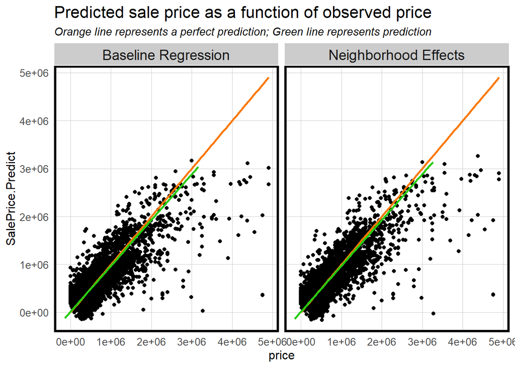

```r
bothRegressions %>%
  dplyr::select(SalePrice.Predict, price, Regression) %>%
    ggplot(aes(price, SalePrice.Predict)) +
  geom_point() +
  stat_smooth(aes(price, price),
             method = "lm", se = FALSE, size = 1, colour="#FA7800") +
  stat_smooth(aes(SalePrice.Predict, price),
              method = "lm", se = FALSE, size = 1, colour="#25CB10") +
  facet_wrap(~Regression) +
  labs(title="Predicted sale price as a function of observed price",
       subtitle="Orange line represents a perfect prediction; Green line represents prediction") +
  plotTheme()
```

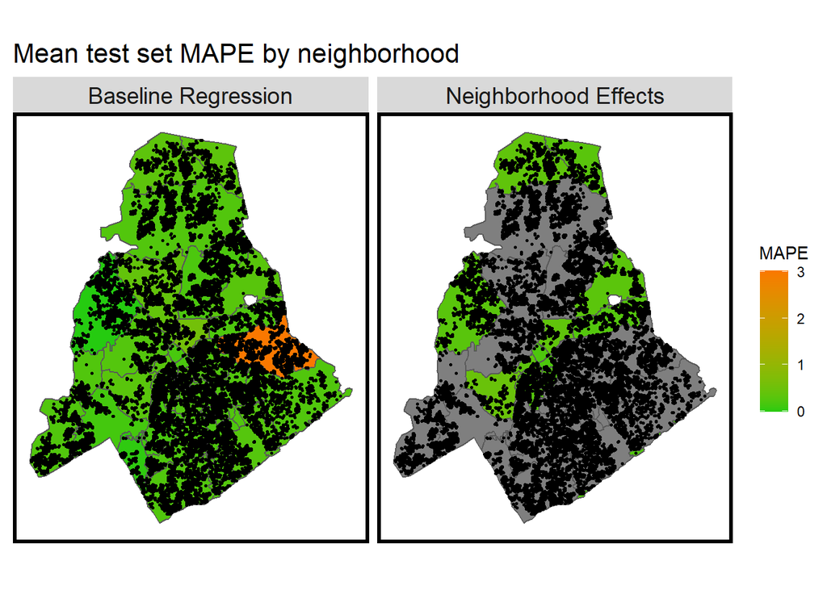

```r
st_drop_geometry(bothRegressions) %>%
  group_by(Regression, zip) %>%
  summarize(mean.MAPE = mean(SalePrice.APE, na.rm = T)) %>%
  ungroup() %>%
  left_join(Mecklenberg) %>%
    st_sf() %>%
    ggplot() +
      geom_sf(aes(fill = mean.MAPE)) +
      geom_sf(data = bothRegressions, colour = "black", size = .5) +
      facet_wrap(~Regression) +
      scale_fill_gradient(low = palette5[1], high = palette5[5],
                          name = "MAPE") +
      labs(title = "Mean test set MAPE by neighborhood") +
      mapTheme()
```

```r
Mecklenberg.training2 <-
  Mecklenberg.training %>%
  mutate(Regression = "Neighborhood Effects",
         SalePrice.Predict = predict(reg.nhood, Mecklenberg.training),
        )
```

```r
CHALLENGE<-
  rbind(Mecklenberg.test.nhood[Mecklenberg.test.nhood$toPredict=="CHALLENGE",c("SalePrice.Predict","musaID")],Mecklenberg.training2[Mecklenberg.training2$toPredict=="CHALLENGE",c("musaID","SalePrice.Predict")])%>%
  st_drop_geometry%>%
  rename(prediction = SalePrice.Predict)%>%
subset(select=c(2,1))

write.csv(CHALLENGE,"SY_group_prediction.csv", row.names = FALSE)
```